# How health insurance coverage pattern varies across time and states?

As my proposal suggests (review my proposal [here](https://docs.google.com/document/d/1XArThcuiPvnkcYWRS6dEQUzbUfkGofiqQAJLyagyebk/edit?usp=sharing)), I am interested in three aspects of health insurance coverage: the variation arcoss time and locations, comparison between demographic data pattern and business data, and the relationship with some socioeconomic indicators. In this report, I would like to explore them in eight type of charts. First, I would explore the holistic situation of U.S., and then take four states as examples to roughly examine the influence of Ombama care.

## Story about U.S.

#### Dempgraphic Pattern vs Business Pattern

The following three Cartograms and three Choropleth maps compare the total health insurance coverage reported by American Community Survey with the number of benefit plans per capita offered in each states in 2014 - 2016. In order to make the demographic data and business data comparable, I use the same source of total population data to calculate counting rates.  
Apparently, there are differences between these two patterns. In terms of total health insurance coverage, the northeastern part of U.S. performs better while the business plans stand out in the mid-north and northwestern part of U.S. Since the report in ACS does not distinguish between private and public insurance sources, it is reasonable to speculate that the public insurance might did a much better job in northeastern states which leads to a fair total covarage in these states. In addition, if we compare the temporal pattern, we could tell that the total health insurance coverage is increasing across years. However, the number of business plans per capitia has a decrease from 2015 to 2016.

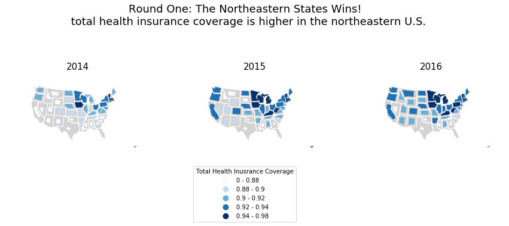

```python
def plot_year_to_ax_legend(df_year, axarr, year):
    scheme = mc.Quantiles(coverage_geo_total['coverage rate'], k=5)
    ax = gplt.cartogram(df_year,scale='coverage rate',
                        hue='coverage rate', scheme=scheme,
                        legend=True,
                        legend_kwargs={'bbox_to_anchor': (0.8, 0),
                                   'title': "Total Health Inusrance Coverage" },
                        legend_var='hue',
                        cmap='Blues', ax=axarr)
    ax.set_title(year, fontsize=15, fontname='fantasy')
    gplt.polyplot(df_year, facecolor='lightgray', edgecolor='white', ax=ax)

def plot_year_to_ax(df_year, axarr, year):
    scheme = mc.Quantiles(coverage_geo_total['coverage rate'], k=5)
    ax = gplt.cartogram(df_year,scale='coverage rate',
                        hue='coverage rate', scheme=scheme,
                        cmap='Blues', ax=axarr)
    ax.set_title(year, fontsize=15, fontname='fantasy')
    gplt.polyplot(df_year, facecolor='lightgray', edgecolor='white', ax=ax)


proj = gcrs.AlbersEqualArea(central_longitude=-98, central_latitude=39.5)
f, axarr = plt.subplots(1, 3, figsize=(15, 6), subplot_kw={'projection': proj}, squeeze=False )

plt.suptitle('Round One: The Northeastern States Wins! \n total health insurance coverage is higher in the northeastern U.S.', fontsize=18, fontname='fantasy')
#plt.title("The eastern states in U.S. have higher insurance coverage across years", fontsize=10, fontname='fantasy')
plt.subplots_adjust(top=0.95)



plot_year_to_ax(coverage_geo2014, axarr[0][0], "2014")

plot_year_to_ax_legend(coverage_geo2015, axarr[0][1], "2015")

plot_year_to_ax(coverage_geo2016, axarr[0][2], "2016")
#plt.legend()
```

```python
configure_plotly_browser_state()
fig = make_subplots(rows=1, cols=2)
data2014 = dict(type = 'choropleth',
           locations = df2014['state'],
           locationmode = 'USA-states',
           colorscale = 'Blues',
           text = df2014['state'],
           marker = dict (line = dict(color = 'rgb(231, 239, 254)',width=2)),
           z = df2014['count rate'],
           zmin = 0,
           zmax = 0.05,
           geo = 'geo')
layout = dict()
layout['geo'] = dict(scope = 'usa',showlakes = True,lakecolor='rgb(231, 239, 254)',
                     domain = dict( x = [0.0, 1/3], y = [0.0, 1.0] ))

data2015 = dict(type = 'choropleth',
           locations = df2015['state'],
           locationmode = 'USA-states',
           colorscale = 'Blues',
           text = df2015['state'],
           marker = dict (line = dict(color = 'rgb(231, 239, 254)',width=2)),
           z = df2015['count rate'],
           zmin = 0,
           zmax = 0.05,
           geo = 'geo2')

layout['geo2'] = dict(scope = 'usa', showlakes = True, lakecolor='rgb(231, 239, 254)',
                      domain = dict( x = [1/3, 2/3], y = [0.0, 1.0] ))

data2016 = dict(type = 'choropleth',
           locations = df2016['state'],
           locationmode = 'USA-states',
           colorscale = 'Blues',
            text = df2016['state'],
            marker = dict (line = dict(color = 'rgb(231, 239, 254)',width=2)),
           z = df2016['count rate'],
           zmin = 0,
           zmax = 0.05,
           geo = 'geo3')

layout['geo3'] = dict(scope = 'usa',showlakes = True,lakecolor='rgb(231, 239, 254)',
                      domain = dict( x = [2/3, 1.0], y = [0.0, 1.0] ))
choromap2 = go.Figure(data = [data2014, data2015, data2016],layout=layout)
choromap2.update_layout(title=dict(
        text = """Round Two: North Central States Wins!""",
        y=0.9,
        x=0.5,
        xanchor='center',
        yanchor='top',
        font=dict(
        family="fantasy",
        size=18,
        color="#2a3f5f")),
       annotations=[
        go.layout.Annotation(
            x= 1/2,
            y=1,
            showarrow=False,
            text="number of benefit plans per captia is higher in north central parts of U.S.",
            xref="paper",
            yref="paper",
            font=dict(
            family="fantasy",
            size=15,
            color="#2a3f5f"
            )
        ),
        go.layout.Annotation(
            x=1/10,
            y=0.8,
            showarrow=False,
            text="2014",
            xref="paper",
            yref="paper",
            font=dict(
            family="droid serif",
            size=15,
            color="#486ca3"
            )
        ),
        go.layout.Annotation(
            x= 1/2,
            y=0.8,
            showarrow=False,
            text="2015",
            xref="paper",
            yref="paper",
            font=dict(
            family="droid serif",
            size=15,
            color="#486ca3"
            )
        ),
        go.layout.Annotation(
            x=5/6,
            y=0.8,
            showarrow=False,
            text="2016",
            xref="paper",
            yref="paper",
            font=dict(
            family="droid serif",
            size=15,
            color="#486ca3"
            )
        )],
        legend=dict(font=dict(
            family="droid serif",
            size=12,
            color="#486ca3"
        )))
iplot(choromap2)
```

[interactive chart not shown]

Data Source:

- insurance coverage rate from The Kaiser Family Foundation: https://www.kff.org/other/state-indicator/total-population/?currentTimeframe=2&sortModel=%7B%22colId%22:%22Location%22,%22sort%22:%22asc%22%7D
- number of benefit plans from kaggle: https://www.kaggle.com/hhs/health-insurance-marketplace#BenefitsCostSharing.csv This data source provides data on health and dental plans offered to individuals and small businesses through the US Health Insurance Marketplace.

#### SES indicator vs health insurance coverage

In this part, I use the coverage and SES data in 2018 to discover the patterns. I displays the relationship between SES indicator and health insurance coverage by comparing scatter plots and heatmaps.

```python
alt.data_transformers.enable('default', max_rows=None)

color_scale = alt.Scale(domain=['coverage: Total', 'Employer',  'Medicaid', 'Medicare'],
                        range=['#64b2ff', '#97cbff', '#b0d8ff', '#e3f1ff'])
base = alt.Chart(sub_coverage_total).mark_point().encode(
    x=alt.X('SES indicator value:Q'),
    y='coverage rate:Q',
    color = alt.Color('coverage type', scale=color_scale),
    shape = 'SES:N',
    column = 'SES:N'
).properties(
    width=160,
    height=160
)

chart = alt.hconcat()
for ses in ['median household income($)', 'annual gdp($)', 'percent population under poverty level(%)']:
    chart |= base.transform_filter(datum.SES == ses)

chart.properties(title=
                 {'text': ["Relationship between SES Indicators and Insurance Coverage Rate (All States, 2018)"],
                 'subtitle': ["The shade of color represents the order of coverage rate for each type and the shape of point represent different socioeconomic indicators.",
                              "Employer insurance covers most people and its coverage rate is affected by the percent population under poverty level."],
                   }).configure_title(align = "center")
```

[interactive chart not shown]

Data Source:

- annual gdp (2008-2018) from Bureau of Economic Analysis (US Department of Commerce): https://apps.bea.gov/regional/downloadzip.cfm
- median household income and percent of population under poverty level from ACS 1-year estimate(2011-2018): https://www.census.gov/data/developers/data-sets/acs-1year.2011.html
- insurance coverage rate from The Kaiser Family Foundation: https://www.kff.org/other/state-indicator/total-population/?currentTimeframe=2&sortModel=%7B%22colId%22:%22Location%22,%22sort%22:%22asc%22%7D

From the charts above, it is obvious to tell that there is a positive relationship between median household income and some types of health insurance coverage. And a negative relationship between percent population under poverty level and insurance coverage. However, the distribution of health insurance type is messy up together and we can barely see any relationship between total health insurance coverage and SES indicators. Therefore, I decided to use a heatmap to examine if there does not exist such a relationship between the total health insurance coverage and SES indicators.

```python
base = alt.Chart(sub_coverage_total[sub_coverage_total['coverage type']=='coverage: Total']).mark_rect().encode(
    alt.Y('coverage rate:Q', bin=alt.Bin(maxbins=20)),
    alt.X('SES indicator value:Q', bin=alt.Bin(maxbins=40)),
    alt.Color('count(coverage rate):Q', scale=alt.Scale(scheme='blues')),
    column = 'SES:N'
).properties(
    width=160,
    height=160
)

chart = alt.hconcat()
for ses in ['median household income($)', 'annual gdp($)', 'percent population under poverty level(%)']:
    chart |= base.transform_filter(datum.SES == ses)

chart.properties(title=
                 {'text': ["Heatmap of SES Indicators and Total Insurance Coverage Rate (All States, 2018)"],
                 'subtitle': ["Positive relationship exists between median household income and total coverge rate",
                              "while negative relationship is between percent population under poverty level and total coverage rate."],
                   }).configure_title(align = "center")
```

[interactive chart not shown]

Data Source:

- annual gdp (2008-2018) from Bureau of Economic Analysis (US Department of Commerce): https://apps.bea.gov/regional/downloadzip.cfm
- median household income and percent of population under poverty level from ACS 1-year estimate(2011-2018): https://www.census.gov/data/developers/data-sets/acs-1year.2011.html
- insurance coverage rate from The Kaiser Family Foundation: https://www.kff.org/other/state-indicator/total-population/?currentTimeframe=2&sortModel=%7B%22colId%22:%22Location%22,%22sort%22:%22asc%22%7D

This heatmap tells us that annual gdp is not helpful to exlaining the divergence in total health insurance coverage across states in 2018. Meanwhile, median household income and percent population under poverty level displays some correlation with total health insurance coverage in terms of states numbers.

#### health insurance coverage by age groups and gender (demographic pattern)

In this part, I use three type of charts to display the demographic patterns: population pyramid, strip plot and grouped bar chart. I would first check population pyramid which providing insights on absolute number of population covered or not. Next, I would calculate the coverage rate by gender and age groups to analyze the patterns among different groups.

```python
slider = alt.binding_range(min=2008, max=2017, step=1)
select_year = alt.selection_single(name='year', fields=['year'],
                                   bind=slider, init={'year': 2008})

base = alt.Chart(test).add_selection(
    select_year
).transform_filter(
    select_year
).transform_calculate(
    gender=alt.expr.if_(alt.datum.sex == 1, 'Male', 'Female')
).properties(
    width=250
)


color_scale_cov = alt.Scale(domain=['Male', 'Female'],
                        range=['#b0d8ff', '#c2d5fc'])

left = base.transform_filter(
    alt.datum.gender == 'Female'
).encode(
    y=alt.Y('age:N', axis=None),
    x=alt.X('sum(covered population):Q',
            title='covered population',
            sort=alt.SortOrder('descending'),
            scale=alt.Scale(domain=(0, 40000))),
    color=alt.Color('gender:N', scale=color_scale_cov, legend=None)
).mark_bar().properties(title='Female')



middle = base.encode(
    y=alt.Y('age:N', axis=None),
    text=alt.Text('age:N'),
).mark_text().properties(width=20)

right = base.transform_filter(
    alt.datum.gender == 'Male'
).encode(
    y=alt.Y('age:N', axis=None),
    x=alt.X('sum(covered population):Q', title='covered population',
            scale=alt.Scale(domain=(0, 40000))),
    color=alt.Color('gender:N', scale=color_scale_cov, legend=None)
).mark_bar().properties(title='Male')

covered = alt.concat(left, middle, right, spacing=5)


color_scale_tot = alt.Scale(domain=['Male', 'Female'],
                        range=['#ffbc70', '#ffe070'])

left = base.transform_filter(
    alt.datum.gender == 'Female'
).encode(
    y=alt.Y('age:N', axis=None),
    x=alt.X('sum(total population ):Q',
            title='total population',
            sort=alt.SortOrder('descending')),
    color=alt.Color('gender:N', scale=color_scale_tot, legend=None)
).mark_bar().properties(title='Female')



middle = base.encode(
    y=alt.Y('age:N', axis=None),
    text=alt.Text('age:N'),
).mark_text().properties(width=20)

right = base.transform_filter(
    alt.datum.gender == 'Male'
).encode(
    y=alt.Y('age:N', axis=None),
    x=alt.X('sum(total population ):Q', title='total population'),
    color=alt.Color('gender:N', scale=color_scale_tot, legend=None)
).mark_bar().properties(title='Male')

total = alt.concat(left, middle, right, spacing=5)

concat = alt.hconcat(covered, total)
concat.properties(title = {
                            'text': ["Population Covered by Government Health Insurance / Total Population by Age groups by Gender"],
                            'subtitle': ["Younger age and elderly people have higher coverage in absolute number.",
                                         "The overall trend is increasing in health insurance coverage."]}).configure_title(align = "center")
concat.resolve_scale(color='independent')
```

[interactive chart not shown]

Data Source:

- data for 2008 - 2012 from Health Insurance Historical Tables - HIB Series table HIB-2：https://www.census.gov/data/tables/time-series/demo/health-insurance/historical-series/hib.html
- data for 2013 - 2017 from Health Insurance Historical Tables - HIC Series table HIC-2: https://www.census.gov/data/tables/time-series/demo/health-insurance/historical-series/hic.html

```python
color_scale = alt.Scale(domain=['Male', 'Female'],
                        range=['#b0d8ff', '#c2d5fc'])
alt.Chart(test).mark_tick(opacity=0.8).encode(
    x='coverage rate:Q',
    y='age:O',
    color='year:O',
    row = 'sex:N'
).transform_calculate(
    "sex", alt.expr.if_(alt.datum.sex == 1, "Male", "Female")).properties(title=
                                                                          {'text':["Coverage Rate by Age Groups and Gender across Years (No.1)"],
                                                                           'subtitle':["Similar to absolute number measurement, there still exist a marsh in labor population groups."]})
```

[interactive chart not shown]

Data Source:

- data for 2008 - 2012 from Health Insurance Historical Tables - HIB Series table HIB-2：https://www.census.gov/data/tables/time-series/demo/health-insurance/historical-series/hib.html
- data for 2013 - 2017 from Health Insurance Historical Tables - HIC Series table HIC-2: https://www.census.gov/data/tables/time-series/demo/health-insurance/historical-series/hic.html

From the strip plot above, we can see more clearly that the coverage rate for all age groups are increasing as time flows. Nevertheless, the marsh in labor population still exist when we consider the coverage rate instead of absolute covered population. The divergence among age groups are narrowing from 2008 to 2017.

```python
color_scale = alt.Scale(domain=['Male', 'Female'],
                        range=['#b0d8ff', '#c2d5fc'])

slider = alt.binding_range(min=2008, max=2017, step=1)
select_year = alt.selection_single(name="year", fields=['year'],
                                   bind=slider, init={'year': 2008})

alt.Chart(test).mark_bar().encode(
    x=alt.X('sex:N', title=None),
    y=alt.Y('coverage rate:Q', scale=alt.Scale(domain=(0, 100))),
    color=alt.Color('sex:N', scale=color_scale),
    column='age:O'
).properties(
    width=20
).add_selection(
    select_year
).transform_calculate(
    "sex", alt.expr.if_(alt.datum.sex == 1, "Male", "Female")
).transform_filter(
    select_year
).configure_facet(
    spacing=8
).properties(title = {'text':["Coverage Rate by Age Groups and Gender across Years (No.2)"],
                  'subtitle':["The female are covered more than the male."]})
```

[interactive chart not shown]

Data Source:

- data for 2008 - 2012 from Health Insurance Historical Tables - HIB Series table HIB-2：https://www.census.gov/data/tables/time-series/demo/health-insurance/historical-series/hib.html
- data for 2013 - 2017 from Health Insurance Historical Tables - HIC Series table HIC-2: https://www.census.gov/data/tables/time-series/demo/health-insurance/historical-series/hic.html

The emphasis on this grouped bar chart is gender. In all age groups, female has a higher coverage rate in terms of total insurance coverage. But such a difference is narrowing down.

## Story about Some States

In the first map, I use cartogram and choropleth to show the differences between states. Here we zoom in to take four states from the eastern coast, midwest, south and western coast to as examples. To answer my last question about Obama care, I plot the temporal change in these states.

Data Source:

- annual gdp (2008-2018) from Bureau of Economic Analysis (US Department of Commerce): https://apps.bea.gov/regional/downloadzip.cfm
- insurance coverage rate from The Kaiser Family Foundation: https://www.kff.org/other/state-indicator/total-population/?currentTimeframe=2&sortModel=%7B%22colId%22:%22Location%22,%22sort%22:%22asc%22%7D

```python
color_scale = alt.Scale(domain=['coverage: Total', 'Employer',  'Medicaid', 'Medicare'],
                        range=['#64b2ff', '#97cbff', '#b0d8ff', '#e3f1ff'])
coverage = alt.Chart(sub_coverage_gdp_long).mark_line().encode(
    x = 'year:O',
    y = 'coverage rate',
    color = alt.Color('coverage type', scale=color_scale),
    size = 'before_2010:O',
    column = 'Location:N'
)
coverage.properties(title={
    'text':["Health Insurance Coverage Change by States and Year"],
    'subtitle':["After 2010, there is decrease in employer insurance and increase in total coverage and mediaid"]
})
```

[interactive chart not shown]

There are some common trends before and after 2010 in these states: a sharp increase in total health insurance coverage appeared around 2013 and around 2016 it smooths down. So, overall, the total health insurance coverage improved since then. The medicaid also increases after 2010. However, the employer insurance decreases after 2010, which corresponds to the one of the major cons of Obama Care. Because Many businesses found it more cost-effective to pay the penalty and let their employees purchase insurance plans on the exchanges. Other small businesses find they can get better plans through the state-run exchanges.\ Besides that, We can also see the differences: Texas has the lowest total coverage rate but its employer insurance coverage is consistent with California. California has the sharpest increase in total health insurance coverage and medicaid.

Explanation on Theming:

8 Types of Charts:

- cartogram
- choropleth
- scatter plot
- heatmap
- population pyramid
- strip plot
- grouped bar chart
- line plot

Encodings I used:

- color hue: for coverage type
- color saturation: for proportion of coverage type/ change in years
- shape: for ses indicators
- length: for number of population, coverage rate
- position: for genders in population pyramids
- size: before 2010 and after 2010

stevens scale types I used:

- nomial: coverage type, gender
- ordinal: year
- ratio: coverage rate etc.